# Chapter 2 - Loading, Exploring and Modeling the Learning2014 Dataset

##### This week’s object of study was the Learning2014 dataset. The Learning2014 dataset contains the results of a survey whose aim was to map out how different things affect the learning of university students. The data was collected from the students of Introduction to Social Statistics in the fall of 2014 (a course taught by Kimmo Vehkalahti in the University of Helsinki). I will analyse the Learning2014 data by going trough the typical following phases.

- *Load the data*
- *Explore the data*
- *Model the data*

## 1. Load the data

1. Read the data(-frame) from a .csv-file with the read.table -function

## 2. Exploring and Visualizing the data

1. Show the structure of the dataframe with the str() function

```r
str(lrn2014[-1])
```

```
## 'data.frame':    166 obs. of  7 variables:
##  $ gender  : Factor w/ 2 levels "F","M": 1 2 1 2 2 1 2 1 2 1 ...
##  $ Age     : int  53 55 49 53 49 38 50 37 37 42 ...
##  $ attitude: num  3.7 3.1 2.5 3.5 3.7 3.8 3.5 2.9 3.8 2.1 ...
##  $ deep    : num  3.75 2.88 3.88 3.5 3.75 ...
##  $ stra    : num  3.38 2.75 3.62 3.12 3.62 ...
##  $ surf    : num  2.58 3.17 2.25 2.25 2.83 ...
##  $ Points  : int  25 12 24 10 22 21 21 31 24 26 ...
```

2. Show the dimensions of the dataframe with the dim() function

```r
dim(lrn2014[-1])
```

```
## [1] 166   7
```

3. Show 10 first observations by using the head() -function

```r
head(lrn2014[-1], 10)
```

```
##    gender Age attitude  deep  stra     surf Points
## 1       F  53      3.7 3.750 3.375 2.583333     25
## 2       M  55      3.1 2.875 2.750 3.166667     12
## 3       F  49      2.5 3.875 3.625 2.250000     24
## 4       M  53      3.5 3.500 3.125 2.250000     10
## 5       M  49      3.7 3.750 3.625 2.833333     22
## 6       F  38      3.8 4.875 3.625 2.416667     21
## 7       M  50      3.5 4.250 2.250 1.916667     21
## 8       F  37      2.9 3.500 4.000 2.833333     31
## 9       M  37      3.8 4.500 4.250 2.166667     24
## 10      F  42      2.1 4.000 3.500 3.000000     26
```

#### Visualize the data by plotting it

##### Show a graphical overview and summaries of the data (2.2)

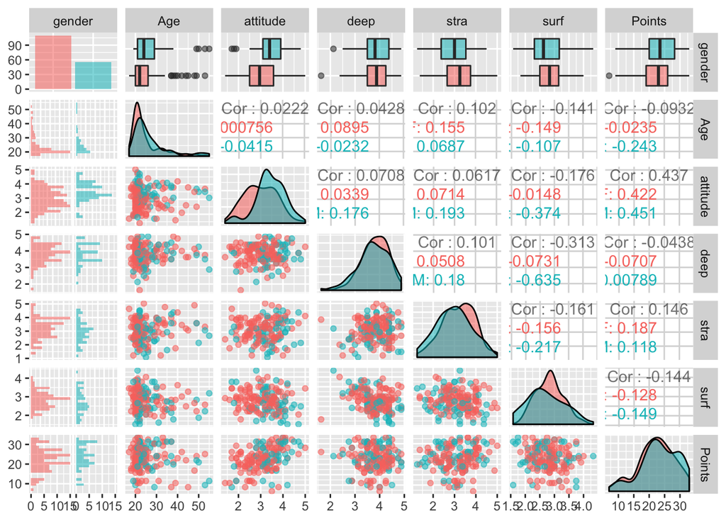

```r
ggpairs(lrn2014[-1], mapping = aes(col = gender, alpha = 0.3), lower = list(combo = wrap("facethist", bins = 20)))
```

```r
### p2 <- pairs(learning2014, , col=learning2014$gender)
```

## 3. Modeling the Data

#### Exam points as the dependent variable and age, gender and attitude as explanatory variables

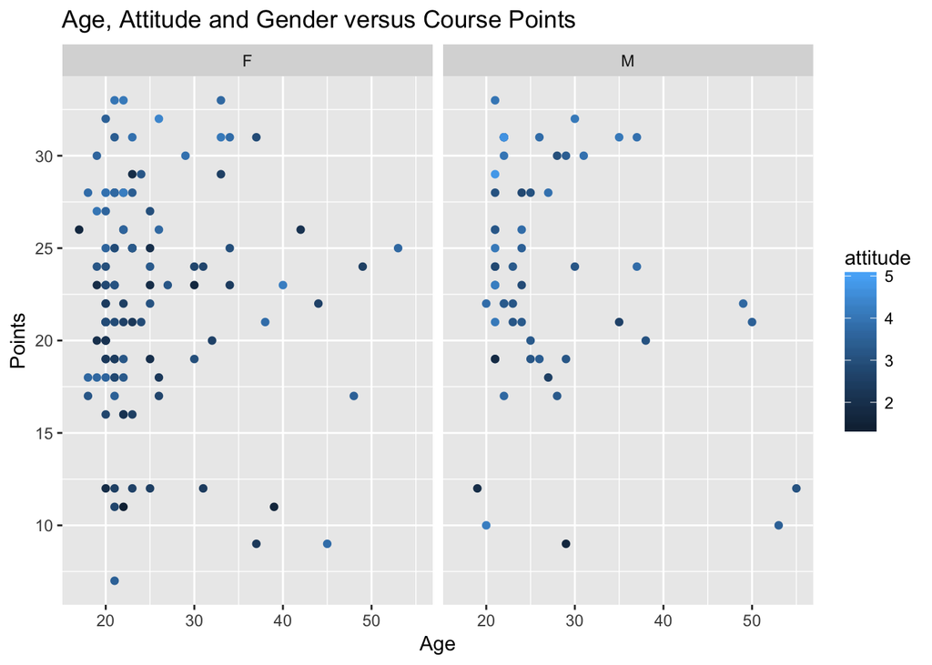

```r
ggplot(lrn2014, aes(x= Age, y=Points, col=attitude)) + geom_point() + facet_grid(. ~ gender) + ggtitle("Age, Attitude and Gender versus Course Points")
```

##### Fitting the regession model to the graphic shown above

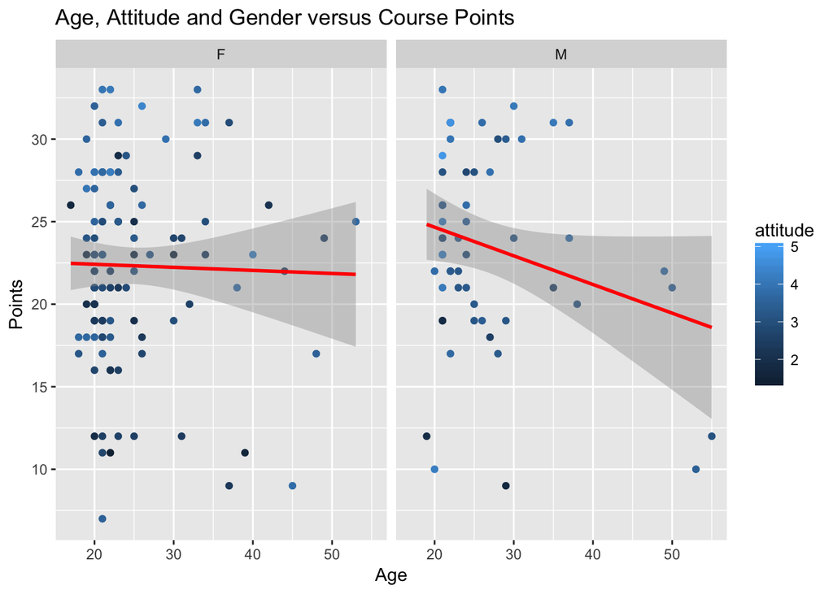

```r
ggplot(lrn2014, aes(x= Age, y=Points, col=attitude)) + geom_point() + facet_grid(. ~ gender) + stat_smooth(method="lm", col="red") + ggtitle("Age, Attitude and Gender versus Course Points")
```

##### Adding a smooth line to the graphic shown above

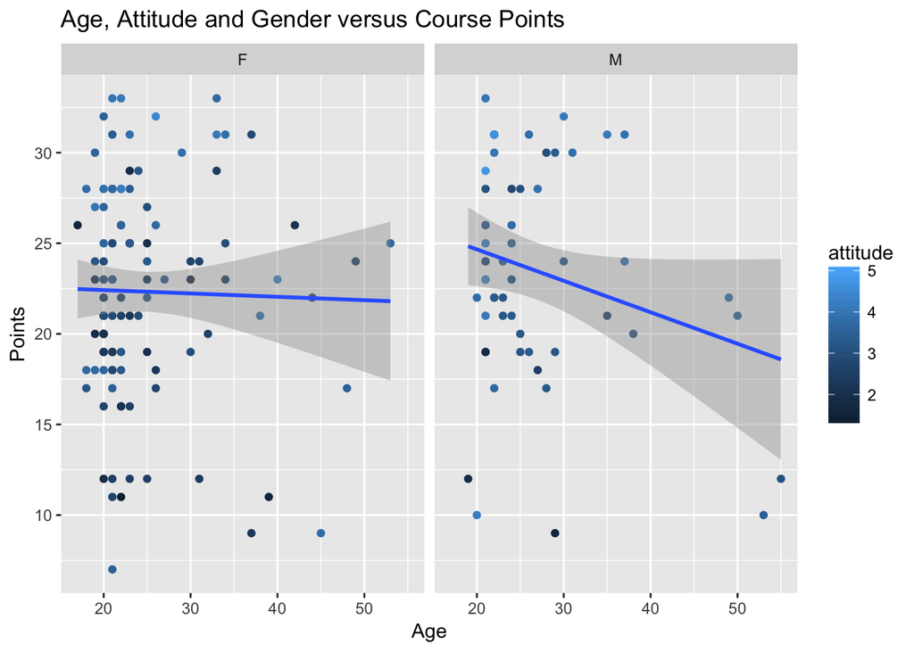

```r
ggplot(lrn2014, aes(x= Age, y=Points, col=attitude)) + geom_point() + geom_smooth(method="lm")  + ggtitle("Age, Attitude and Gender versus Course Points") + facet_grid(. ~ gender)
```

## 4. Summarizing the Fitted Model and Interpreting the Model Parameters

#### The regression model of Age, Attitude and Gender versus Course Points with the summary of the fitted model

From the summary of the regression model below it can be deduced that age and male gender are negatively correlated to course points while attitude affects course points in a very positive way.

```r
my_model2 <- lm(Points ~ Age + gender + attitude, data = lrn2014)
summary(my_model2)
```

```
##
## Call:
## lm(formula = Points ~ Age + gender + attitude, data = lrn2014)
##
## Residuals:
##      Min       1Q   Median       3Q      Max
## -17.4590  -3.3221   0.2186   4.0247  10.4632
##
## Coefficients:
##             Estimate Std. Error t value Pr(>|t|)
## (Intercept) 13.42910    2.29043   5.863 2.48e-08 ***
## Age         -0.07586    0.05367  -1.414    0.159
## genderM     -0.33054    0.91934  -0.360    0.720
## attitude     3.60657    0.59322   6.080 8.34e-09 ***
## ---
## Signif. codes:  0 '***' 0.001 '**' 0.01 '*' 0.05 '.' 0.1 ' ' 1
##
## Residual standard error: 5.315 on 162 degrees of freedom
## Multiple R-squared:  0.2018, Adjusted R-squared:  0.187
## F-statistic: 13.65 on 3 and 162 DF,  p-value: 5.536e-08
```

#### Diagnostic plots

He are some diagnostic plots visualizing the model parameters: Residuals vs Fitted values, Normal QQ-plot and Residuals vs Leverage.

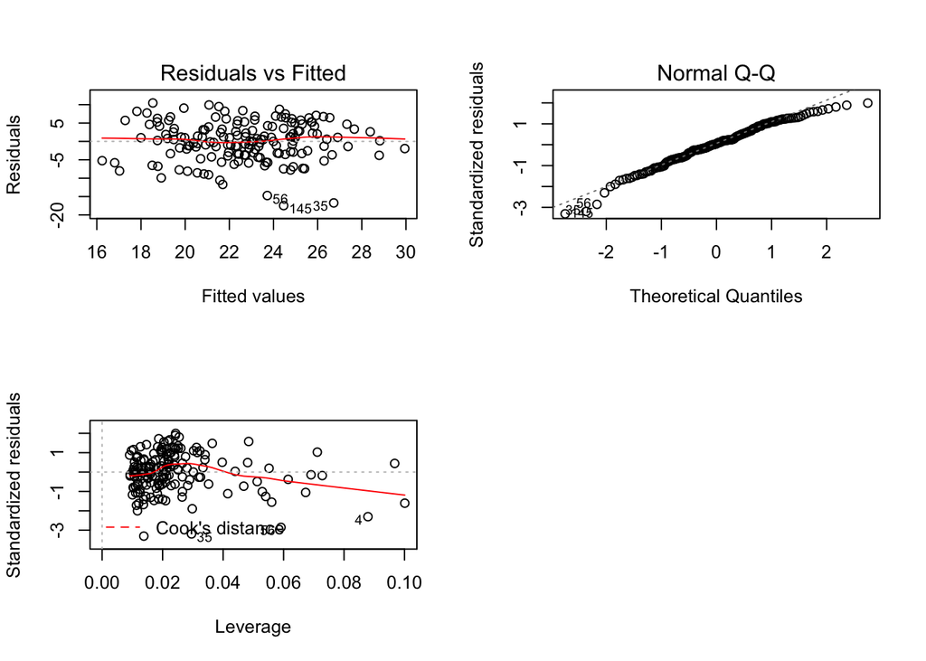